# 1. Data Acquisition

## First, we'll collect statistics for all the videos on the channel, then construct a pandas dataframe with the following attributes:

## date - title - id - views - likes - dislikes - comments - tags - duration - category

```python
#Import required modules
from apiclient.discovery import build
from isodate import parse_duration
from datetime import datetime
import pandas as pd
import numpy as np
import matplotlib.pyplot as plt
import seaborn as sns
```

```python
#set up the credentials of the channel to be scraped
YOUTUBE_API_SERVICE_NAME = "youtube"
YOUTUBE_API_VERSION = "v3"
DEVELOPER_KEY = "AIzaSyD1X_eBJ32cQRxyMswTM-bCjjebPWTMD_g"

youtube = build(YOUTUBE_API_SERVICE_NAME,YOUTUBE_API_VERSION,developerKey=DEVELOPER_KEY)
```

```python
#CHANNEL INFORMATION : description, start date, Channel ID ...
def youtubeSearch(query, max_results=50,order="relevance", token=None, location=None, location_radius=None):
    #search upto max 50 videos based on query
    search_response = youtube.search().list(
                                        q=query,
                                        type="channel",
                                        pageToken=token,
                                        order = order,
                                        part="id,snippet",
                                        maxResults=max_results,
                                        location=location,
                                        locationRadius=location_radius).execute()

    print("Search Completed...")
    print("Total results: {0} \nResults per page: {1}".format(search_response['pageInfo']['totalResults'], search_response['pageInfo']['resultsPerPage']))
    print("Example output per item, snippet")
    print(search_response['items'][0]['snippet'].keys())
    #Assign first page of results (items) to item variable
    items = search_response['items'] #50 "items"
    #Assign 1st results to title, channelId, datePublished then print
    title = items[0]['snippet']['title']
    desc = search_response['items'][0]['snippet']['description']
    channelId = items[0]['snippet']['channelId']
    datePublished = items[0]['snippet']['publishedAt']
    print("First result is: \n Title: {0} \n Description: {1} \n Channel ID: {2} \n Published on: {3}".format(title, desc, channelId, datePublished))

    return search_response


response = youtubeSearch('MBC مصر')
```

```
Search Completed...
Total results: 2334
Results per page: 50
Example output per item, snippet
dict_keys(['publishedAt', 'channelId', 'title', 'description', 'thumbnails', 'channelTitle', 'liveBroadcastContent'])
First result is:
 Title: MBC مصر
 Description: خرجت MBC مصر إلى النور في شهر نوفمبر/ تشرين الثاني من عام 2012 ، لتقدم تغطية متميزة للشأن المصري بكافة أبعاده....
 Channel ID: UCnFKsbAof9fRv614I4wJX_w
 Published on: 2012-10-14T17:38:53.000Z
```

```python
def get_channel_videos(channel_id):

    # get Uploads playlist id
    res = youtube.channels().list(id=channel_id,
                                  part='contentDetails,statistics').execute()
    stat = res  #to extract channel statistics
    playlist_id = res['items'][0]['contentDetails']['relatedPlaylists']['uploads']

    videos = []
    next_page_token = None

    while 1:
        res = youtube.playlistItems().list(playlistId=playlist_id,
                                           part='snippet',
                                           maxResults=50,
                                           pageToken=next_page_token).execute()

        videos += res['items']
        next_page_token = res.get('nextPageToken')

        if next_page_token is None:
            break


    return videos, stat

channel_id = response['items'][0]['snippet']['channelId']
videos, stat = get_channel_videos(channel_id)
```

```python
print("channel statistics: ")
print("  no. of videos on MBC masr ",len(videos))
print("  Subscribers ", stat['items'][0]['statistics']['subscriberCount']  )
print("  View Count " ,stat['items'][0]['statistics']['viewCount'])
```

```
channel statistics:
  no. of videos on MBC masr  21913
  Subscribers  7390000
  View Count  4682808901
```

```python
for video in videos[:5]:
    print(video['snippet']['title'])
```

```
أشرف قاسم: تأجيل قمة الدوري مشكلة
أشرف قاسم يتوقع مشاركة وليد سليمان كأساسي
حمادة طلبة: أتمنى من لاعبي الزمالك التركيز وعدم المبالغة في الفرحة بالسوبر الإفريقي
ما العنوان المناسب التى تضعه لكتاب مباراة السوبر
أحمد حسن: كهربا في إنتظاره ماتش صعب مع جمهور الزمالك
```

### Get statistics for each video

```python
def get_videos_stats(video_ids):
    stats = []
    for i in range(0, len(video_ids), 50):
        res = youtube.videos().list(id=','.join(video_ids[i:i+50]),
                                   part='contentDetails, statistics, snippet').execute()
        stats += res['items']

    return stats

video_ids = list(map(lambda x:x['snippet']['resourceId']['videoId'], videos))
stats = get_videos_stats(video_ids)
```

```python
stats = sorted(stats, key=lambda x:int(x['statistics']['viewCount']), reverse=True)
```

```python
items=[]

for i in range(len(stats)):
    items.append(
    [stats[i]['snippet']['publishedAt'], stats[i]['snippet']['categoryId'], stats[i]['snippet']['title'],stats[i]['id'],
     stats[i]['statistics'].get('viewCount') , stats[i]['statistics'].get('likeCount'),
     stats[i]['statistics'].get('dislikeCount'), stats[i]['statistics'].get('commentCount')
    , stats[i]['contentDetails'].get('duration'), stats[i]['snippet'].get('tags')]
        )
```

```python
data_videos =pd.DataFrame(items,columns=['date','categoryId','title','id','view','likes','dislikes','comments','duration','tags'])

data_videos.head()
```

|  | date | categoryId | title | id | view | likes | dislikes | comments | duration | tags |
| --- | --- | --- | --- | --- | --- | --- | --- | --- | --- | --- |
| 0 | 2016-06-09T20:29:48.000Z | 24 | خناقة رفاعي مع عيلة النمر فى مسلسل الأسطورة لل... | qpHSPaSV678 | 96386205 | 399840 | 46847 | 0 | PT4M47S | [MBC, MBC Masr, MBCمصر, مصر, Egypt, يحدث فى مص... |
| 1 | 2017-06-03T18:03:27.000Z | 24 | رمضان صبحي ينطق الشهادتين أمام سحلية رامز تحت ... | 5984bdz0ngo | 49309632 | 115177 | 33038 | 0 | PT2M32S | [MBC, MBC Masr, MBCمصر, مصر, Egypt, يحدث فى مص... |
| 2 | 2016-09-02T19:21:16.000Z | 24 | تقليد كوميدي لخناقة رفاعي وعصام النمر فى الأسط... | tIjiDpgN8x4 | 40363238 | 170389 | 14437 | 2 | PT2M31S | [MBC, MBC Masr, MBCمصر, مصر, Egypt, يحدث فى مص... |
| 3 | 2017-12-30T19:38:40.000Z | 10 | محمد أسامه يبدع في غناء عز الحبابيب | 5LLP-KMlaI0 | 35706924 | 249275 | 9223 | 5268 | PT1M48S | [#MBCTheVoiceKids] |
| 4 | 2017-05-30T00:00:51.000Z | 1 | بالطول والعرض .. #رامز_تحت_الأرض | uUIo4Us9dDQ | 35680296 | 129000 | 22004 | 5359 | PT1M40S | None |

#### The Date isn't in standard format, let's convert it.

```python
data_videos['date'] =  pd.to_datetime(data_videos.date, format='%Y-%m-%dT%H:%M:%S.%fZ')
data_videos['Day'] = data_videos.date.dt.day
data_videos['Month'] = data_videos.date.dt.month
data_videos['Year'] = data_videos.date.dt.year
data_videos['Hr'] = data_videos.date.dt.hour
```

#### The Date is formatted as an ISO 8601 string. PT stands for Time Duration, 4M is 4 minutes, and 13S is 13 seconds

```python
data_videos['duration']=data_videos['duration'].apply(lambda x: parse_duration(x).seconds)
```

```python
data_videos.head()
```

|  | date | categoryId | title | id | view | likes | dislikes | comments | duration | tags | Day | Month | Year | Hr |
| --- | --- | --- | --- | --- | --- | --- | --- | --- | --- | --- | --- | --- | --- | --- |
| 0 | 2016-06-09 20:29:48 | 24 | خناقة رفاعي مع عيلة النمر فى مسلسل الأسطورة لل... | qpHSPaSV678 | 96386205 | 399840 | 46847 | 0 | 287 | [MBC, MBC Masr, MBCمصر, مصر, Egypt, يحدث فى مص... | 9 | 6 | 2016 | 20 |
| 1 | 2017-06-03 18:03:27 | 24 | رمضان صبحي ينطق الشهادتين أمام سحلية رامز تحت ... | 5984bdz0ngo | 49309632 | 115177 | 33038 | 0 | 152 | [MBC, MBC Masr, MBCمصر, مصر, Egypt, يحدث فى مص... | 3 | 6 | 2017 | 18 |
| 2 | 2016-09-02 19:21:16 | 24 | تقليد كوميدي لخناقة رفاعي وعصام النمر فى الأسط... | tIjiDpgN8x4 | 40363238 | 170389 | 14437 | 2 | 151 | [MBC, MBC Masr, MBCمصر, مصر, Egypt, يحدث فى مص... | 2 | 9 | 2016 | 19 |
| 3 | 2017-12-30 19:38:40 | 10 | محمد أسامه يبدع في غناء عز الحبابيب | 5LLP-KMlaI0 | 35706924 | 249275 | 9223 | 5268 | 108 | [#MBCTheVoiceKids] | 30 | 12 | 2017 | 19 |
| 4 | 2017-05-30 00:00:51 | 1 | بالطول والعرض .. #رامز_تحت_الأرض | uUIo4Us9dDQ | 35680296 | 129000 | 22004 | 5359 | 100 | None | 30 | 5 | 2017 | 0 |

### we have structured data so let's save the dataframe to a csv file.

```python
data_videos.to_csv("C:\\Users\\zahra\\Desktop\\data.csv",index=False)
```

```python
data_videos = pd.read_csv("C:\\Users\\zahra\\Desktop\\data.csv")
```

### Data Processing

```python
data_videos.isnull().sum()
```

```
date              0
categoryId        0
title             0
id                0
view              0
likes             9
dislikes          9
comments         10
duration          0
tags          10317
Day               0
Month             0
Year              0
Hr                0
dtype: int64
```

```python
#Replacing missing values to Unknown and 0
data_videos['tags'] = data_videos['tags'].fillna("Unknown")
data_videos['likes'] = data_videos['likes'].fillna(0)
data_videos['comments'] = data_videos['comments'].fillna(0)
data_videos['dislikes'] = data_videos['dislikes'].fillna(0)
```

```python
data_videos.isnull().sum()
```

```
date          0
categoryId    0
title         0
id            0
view          0
likes         0
dislikes      0
comments      0
duration      0
tags          0
Day           0
Month         0
Year          0
Hr            0
dtype: int64
```

## Get Comments for each video

```python
def get_video_comments(service, **kwargs):
    comments = []
    v = []
    t =[]
    results = service.commentThreads().list (**kwargs).execute()
    i=0
    while results and i<10:
        for item in results['items']:
            comment = item['snippet']['topLevelComment']['snippet']['textDisplay']
            vid = item['snippet']['topLevelComment']['snippet']['videoId']
            postdate = item['snippet']['topLevelComment']['snippet']['publishedAt']
            vrate = item['snippet']['topLevelComment']['snippet']['viewerRating']
            likeCount = item['snippet']['topLevelComment']['snippet']['likeCount']
            comments.append([comment,vid,postdate,vrate,likeCount])
            v.append(vid)
            t.append (postdate)

        # Check if another page exists
        if 'nextPageToken' in results:
            kwargs['pageToken'] = results['nextPageToken']
            results = service.commentThreads().list(**kwargs).execute()
        else:
            break
        i+=1
    return  comments
```

```python
comments = get_video_comments(youtube, part='snippet',
                              allThreadsRelatedToChannelId=channel_id,
                              maxResults = 100, textFormat='plainText')
```

```python
commentsdf = pd.DataFrame(comments, columns = ['comment','vid','postdate','vrate','likeCount'])
commentsdf.to_csv('C:\\Users\\zahra\\Desktop\\comments.csv')

commentsdf.head()
```

|  | comment | vid | postdate | vrate | likeCount |
| --- | --- | --- | --- | --- | --- |
| 0 | الشعب كلو بيسمع مهرجانات محسسني ان اول مرة تسم... | mg_nFaZsKZM | 2020-02-19T02:32:56.000Z | none | 0 |
| 1 | هو المسح الجماعى ده فين وبيتعملى فين وامتى احن... | EN9j_Ssnu_o | 2020-02-19T02:29:40.000Z | none | 0 |
| 2 | بطلو تعريص بقا | mg_nFaZsKZM | 2020-02-19T02:24:44.000Z | none | 0 |
| 3 | https://youtu.be/9uAtO7zfSPw\nمحمد منير | wrLAR4YYQ7s | 2020-02-19T02:15:18.000Z | none | 0 |
| 4 | احم احم بانسبة لمحمد رمضان \n\nمش اسفاف برضو | eeWW-g_LHo4 | 2020-02-19T02:13:47.000Z | none | 0 |

# 2. Data Exploration

#### Let's start looking if Views, likes, dislikes and comment counts have a normal distribuition

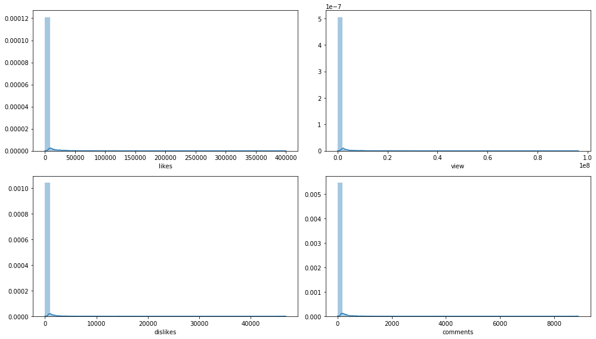

```python
fig, axes = plt.subplots(2, 2)
fig.set_figwidth(14)
fig.set_figheight(8)

sns.distplot((data_videos['likes']), ax = axes[0][0])
sns.distplot((data_videos['view']), ax = axes[0][1])
sns.distplot((data_videos['dislikes']), ax = axes[1][0])
sns.distplot((data_videos['comments']), ax = axes[1][1])

plt.tight_layout()
plt.show()
```

#### as we can see from above likes, views, dislikes and comment_count are not normally distributes, so we transform these values

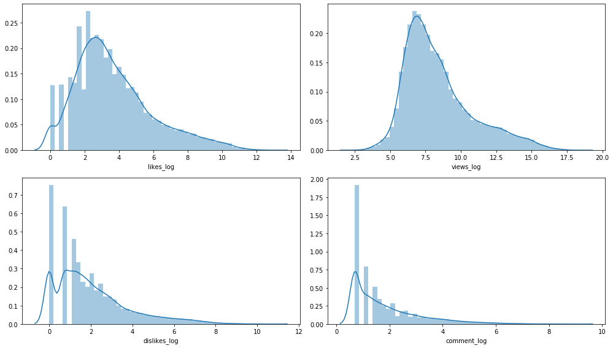

```python
data_videos['likes_log'] = (np.log(data_videos['likes']+ 1))
data_videos['views_log'] = (np.log(data_videos['view']+ 1))
data_videos['dislikes_log'] = (np.log(data_videos['dislikes'] + 1))
data_videos['comment_log'] = (np.log(data_videos['comments'] + 2))

fig, axes = plt.subplots(2, 2)
fig.set_figwidth(14)
fig.set_figheight(8)

sns.distplot((data_videos['likes_log']), ax = axes[0][0])
sns.distplot((data_videos['views_log']), ax = axes[0][1])
sns.distplot((data_videos['dislikes_log']), ax = axes[1][0])
sns.distplot((data_videos['comment_log']), ax = axes[1][1])



plt.tight_layout()
plt.show()
```

#### now it's better, seems like the views are normally distributed on a log scale.

```python
data_videos.sort_values(by='view',ascending=False)[:20]
```

|  | date | categoryId | title | id | view | likes | dislikes | comments | duration | tags | Day | Month | Year | Hr | likes_log | views_log | dislikes_log | comment_log |
| --- | --- | --- | --- | --- | --- | --- | --- | --- | --- | --- | --- | --- | --- | --- | --- | --- | --- | --- |
| 0 | 2016-06-09 20:29:48 | 24 | خناقة رفاعي مع عيلة النمر فى مسلسل الأسطورة لل... | qpHSPaSV678 | 96386205 | 399840.0 | 46847.0 | 0.0 | 287 | ['MBC', 'MBC Masr', 'MBCمصر', 'مصر', 'Egypt', ... | 9 | 6 | 2016 | 20 | 12.898822 | 18.383874 | 10.754664 | 0.693147 |
| 1 | 2017-06-03 18:03:27 | 24 | رمضان صبحي ينطق الشهادتين أمام سحلية رامز تحت ... | 5984bdz0ngo | 49309632 | 115177.0 | 33038.0 | 0.0 | 152 | ['MBC', 'MBC Masr', 'MBCمصر', 'مصر', 'Egypt', ... | 3 | 6 | 2017 | 18 | 11.654234 | 17.713630 | 10.405444 | 0.693147 |
| 2 | 2016-09-02 19:21:16 | 24 | تقليد كوميدي لخناقة رفاعي وعصام النمر فى الأسط... | tIjiDpgN8x4 | 40363238 | 170389.0 | 14437.0 | 2.0 | 151 | ['MBC', 'MBC Masr', 'MBCمصر', 'مصر', 'Egypt', ... | 2 | 9 | 2016 | 19 | 12.045845 | 17.513430 | 9.577619 | 1.386294 |
| 3 | 2017-12-30 19:38:40 | 10 | محمد أسامه يبدع في غناء عز الحبابيب | 5LLP-KMlaI0 | 35706924 | 249275.0 | 9223.0 | 5268.0 | 108 | ['#MBCTheVoiceKids'] | 30 | 12 | 2017 | 19 | 12.426316 | 17.390855 | 9.129564 | 8.569786 |
| 4 | 2017-05-30 00:00:51 | 1 | بالطول والعرض .. #رامز_تحت_الأرض | uUIo4Us9dDQ | 35680296 | 129000.0 | 22004.0 | 5359.0 | 100 | Unknown | 30 | 5 | 2017 | 0 | 11.767575 | 17.390109 | 9.999025 | 8.586906 |
| 5 | 2017-01-13 22:41:09 | 23 | على ربيع يخرج عن النص ويطلب من ويزو طلب كوميدى... | u8zx_hr2t9c | 34683646 | 146545.0 | 17509.0 | 3665.0 | 142 | ['MBC', 'MBC Masr', 'MBCمصر', 'مصر', 'Egypt', ... | 13 | 1 | 2017 | 22 | 11.895095 | 17.361779 | 9.770527 | 8.207129 |
| 6 | 2015-10-24 22:14:42 | 24 | تفاعل الجمهور مع حامد بشكل أكثر من رائع .. شا... | wHELCNX8Ppo | 27656292 | 151145.0 | 9038.0 | 0.0 | 159 | ['MBC', 'MBC Masr', 'MBCمصر', 'مصر', 'Egypt', ... | 24 | 10 | 2015 | 22 | 11.926002 | 17.135364 | 9.109304 | 0.693147 |
| 7 | 2016-06-20 20:50:25 | 24 | ناصر الدسوقي يسترجع أبن أخته و يوجه رسالة قوي... | vX9vA3T4J_8 | 27533396 | 104913.0 | 7505.0 | 0.0 | 104 | ['MBC', 'MBC Masr', 'MBCمصر', 'مصر', 'Egypt', ... | 20 | 6 | 2016 | 20 | 11.560896 | 17.130910 | 8.923458 | 0.693147 |
| 8 | 2017-12-30 20:15:43 | 10 | محمد خشاب يتألق بغناء "خفيف الروح" | ba9LMydPhiM | 27515435 | 164173.0 | 8822.0 | 3675.0 | 112 | Unknown | 30 | 12 | 2017 | 20 | 12.008682 | 17.130258 | 9.085117 | 8.209852 |
| 9 | 2017-01-20 21:01:20 | 24 | على ربيع يتحدي ويزو مين اللي هايقدر يشيل التان... | 4bmUqRdXX2Y | 26365245 | 128655.0 | 13448.0 | 0.0 | 213 | ['MBC', 'MBC Masr', 'MBCمصر', 'مصر', 'Egypt', ... | 20 | 1 | 2017 | 21 | 11.764897 | 17.087557 | 9.506660 | 0.693147 |
| 10 | 2015-11-14 16:15:18 | 24 | حامد يقلد أصوات الفنانين بتألق بداية من علي ال... | q6qM32PyiTI | 26324973 | 210189.0 | 9560.0 | 0.0 | 308 | ['MBC', 'MBC Masr', 'MBCمصر', 'مصر', 'Egypt', ... | 14 | 11 | 2015 | 16 | 12.255767 | 17.086029 | 9.165448 | 0.693147 |
| 11 | 2018-06-07 23:35:23 | 24 | تجميعة لأحلى مشاهد لعلي ربيع في الموسم الرابع ... | jS-hY-Ngi4E | 25963622 | 148893.0 | 14389.0 | 0.0 | 1200 | ['MBC', 'MBC Masr', 'MBCمصر', 'مصر', 'Egypt', ... | 7 | 6 | 2018 | 23 | 11.910990 | 17.072207 | 9.574289 | 0.693147 |
| 12 | 2016-09-09 18:19:37 | 24 | #مسرح_مصر \| فيديو كوميدي لمحمد أنور وكريم عفيف... | I90jO8dTta0 | 25805508 | 84526.0 | 16625.0 | 0.0 | 120 | ['MBC', 'MBC Masr', 'MBCمصر', 'مصر', 'Egypt', ... | 9 | 9 | 2016 | 18 | 11.344826 | 17.066099 | 9.718723 | 0.693147 |
| 13 | 2016-06-24 20:35:08 | 24 | أول لقاء بين ناصر و تمارا بعد ما رفضته تفتكروا... | CcHDI_rPypg | 25679717 | 110872.0 | 6748.0 | 0.0 | 132 | ['MBC', 'MBC Masr', 'MBCمصر', 'مصر', 'Egypt', ... | 24 | 6 | 2016 | 20 | 11.616141 | 17.061212 | 8.817150 | 0.693147 |
| 14 | 2016-07-03 20:36:05 | 24 | ناصر يقتل أمين ومرسي يترجاه بأن لايقتله فكان ر... | uiYeVab-LhM | 23381237 | 82641.0 | 6946.0 | 0.0 | 94 | ['MBC', 'MBC Masr', 'MBCمصر', 'مصر', 'Egypt', ... | 3 | 7 | 2016 | 20 | 11.322273 | 16.967444 | 8.846065 | 0.693147 |
| 15 | 2016-06-20 20:17:21 | 24 | لحظة الانتقام .. ناصر ينتقم من عصام النمر ويأخ... | QzQmh7phVTQ | 23064137 | 77808.0 | 7826.0 | 0.0 | 130 | ['MBC', 'MBC Masr', 'MBCمصر', 'مصر', 'Egypt', ... | 20 | 6 | 2016 | 20 | 11.262012 | 16.953790 | 8.965335 | 0.693147 |
| 16 | 2015-09-05 20:33:42 | 24 | مسرح مصر - على ربيع : خلاص نسيتني .. اومال عا... | RFuXetBC07M | 22925551 | 102176.0 | 6739.0 | 0.0 | 246 | ['MBC', 'MBC MAsr', 'MBC مصر', 'مسرح مصر', 'عل... | 5 | 9 | 2015 | 20 | 11.534462 | 16.947763 | 8.815815 | 0.693147 |
| 17 | 2015-07-22 19:42:20 | 24 | نهاية سعيدة لمسلسل ولى العهد .. وأغنية "يارب ب... | Xs2_q6D9vWM | 22272583 | 75680.0 | 11622.0 | 0.0 | 206 | ['ولى العهد', 'حماده هلال', 'علا غانم', 'انتصا... | 22 | 7 | 2015 | 19 | 11.234282 | 16.918867 | 9.360741 | 0.693147 |
| 18 | 2015-10-03 21:46:11 | 24 | مسرح مصر - التخسيس على طريقة على ربيع الكوميدية | _kvbFItd6oQ | 21892836 | 99553.0 | 6853.0 | 0.0 | 150 | ['MBC', 'MBC Masr', 'MBCمصر', 'مصر', 'Egypt', ... | 3 | 10 | 2015 | 21 | 11.508455 | 16.901670 | 8.832588 | 0.693147 |
| 19 | 2018-07-28 22:00:58 | 1 | علي ربيع يخرج عن النص ويوجه رسالة كوميدية لـ ج... | FZBslmHPSJE | 20087444 | 144907.0 | 6089.0 | 2754.0 | 123 | ['علي ريع'] | 28 | 7 | 2018 | 22 | 11.883854 | 16.815606 | 8.714403 | 7.921536 |

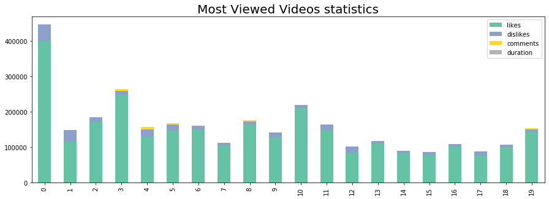

```python
pd.DataFrame(data_videos.sort_values(by='view',ascending=False)[['likes','dislikes','comments','duration']][:20]).plot(kind='bar',stacked=True,figsize=(15,5),use_index=False, cmap=plt.cm.get_cmap("Set2", len(data_videos.index)))
plt.title('Most Viewed Videos statistics',fontdict={'fontsize':20})
```

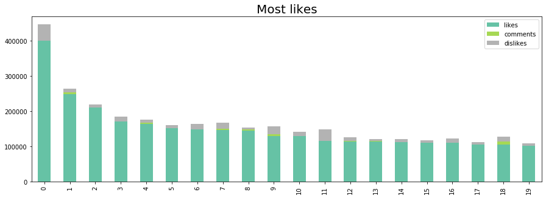

```python
data_videos.sort_values(by='likes',ascending=False)[['likes','comments','dislikes',]][:20].plot(kind='bar',stacked=True,figsize=(15,5),use_index=False, cmap='Set2')
plt.title('Most likes',fontdict={'fontsize':20});
```

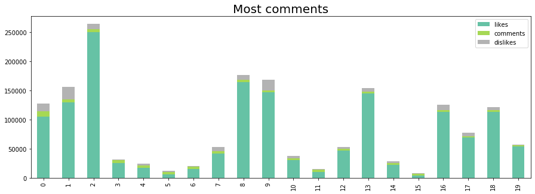

```python
data_videos.sort_values(by='comments',ascending=False)[['likes','comments','dislikes']][:20].plot(kind='bar',stacked=True,figsize=(15,5),use_index=False, cmap='Set2')
plt.title('Most comments',fontdict={'fontsize':20})
```

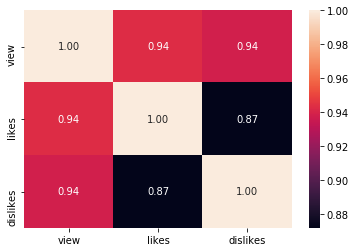

```python
sns.heatmap(data_videos[['view','likes','dislikes']].corr(), annot=True, fmt=".2f")
plt.show()
```

# 3. Data Analysis

### create some new variables to analyse the percent of likes, dislikes, comment by each category to discover what category have the highest correlation.

```python
data_videos['like_rate'] =  data_videos['likes'] / data_videos['view'] * 100
data_videos['dislike_rate'] =  data_videos['dislikes'] / data_videos['view'] * 100
data_videos['comment_rate'] =  data_videos['comments'] / data_videos['view'] * 100
```

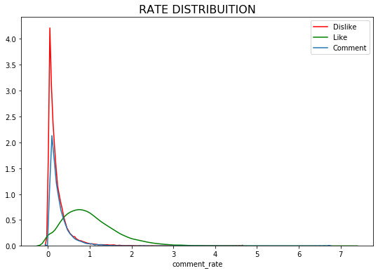

```python
plt.figure(figsize = (9,6))

g1 = sns.distplot(data_videos['dislike_rate'], color='red',hist=False, label="Dislike")
g1 = sns.distplot(data_videos['like_rate'], color='green',hist=False, label="Like")
g1 = sns.distplot(data_videos['comment_rate'],hist=False,label="Comment")
g1.set_title('RATE DISTRIBUITION', fontsize=16)
plt.legend()
plt.show()
```

## Let's define how likely that videos makes people comment. the ratio will equal comments/views

```python
data_videos['discussion_factor']=data_videos['comments']/data_videos['view']
```

### These are the the videos that has the most comments per view let's see their titles

```python
pd.DataFrame(np.arange(0,20),(data_videos[data_videos['view']>1000].sort_values(by='discussion_factor',ascending=False)['title'])[:20])
```

| title | 0 |
| --- | --- |
| #الحكاية \| تناقضات الإخوان في تناولهم الشأن المصري والتركي | 0 |
| النيابة الإدارية تُحيل 4 متهمين للمحاكمة بعد استيلائهم على أموال من مشروع تكافل وكرامة | 1 |
| 70% من جمهور الحكاية يرفض تدريس "الثقافة الجنسية".. خبير تربوي يحلل نسبة التصويت | 2 |
| قبل بداية المدارس.. إزاي نقدر ننمي الابداع الدراسي لأطفالنا؟ | 3 |
| بوادر مؤتمر وطني جديد للشباب مع بدء مبادرة "اسأل الرئيس" في تلقي الأسئلة | 4 |
| ماهو السن المناسب لتدريس مادة الثقافة الجنسية؟.. استشاري طب نفسي للأطفال يكشف الشروط | 5 |
| "الثانوية العامة" تختفي في 2021 والامتحانات تكون على مستوى المدرسة | 6 |
| بيان "الخارجية المصرية" بشأن إخلاء سبيل المواطن السوداني المضبوط في أحداث 20 سبتمبر | 7 |
| خبز البروسكاتا.. وصفة لذيذة وسريعة التحضير | 8 |
| عمرو أديب يتعجب من هجوم أنصار قيس سعيد على مصر: عمرنا ما تدخلنا في الشأن الداخلي التونسي | 9 |
| هاتفياً من جينيف حسين قنيبر مراسل قناة "العربية " يكشف لـ الحكاية آخر تطورات الوضع في الجزائر | 10 |
| #الحكاية \| عمرو أديب: اتركوا قضية محمود البنا للقضاء | 11 |
| #الحكاية \| عمرو أديب يناشد فيس بوك للتصدي للحسابات المزيفة والمنصات التي تروج للشائعات | 12 |
| عمرو أديب يعلق على فيديوهات سابقة لمحمد مرسي والإخوان يتحدثون فيها عن حلول لقضية "سد النهضة" | 13 |
| عمرو اديب منفعلاً : "أبو تريكة" ليس الفضل في فوزنا بتنظيم كأس أمم أفريقيا #الحكاية  | 14 |
| مهيب عبد الهادي : أى مباراة فى ملعب الجونة نتيجتها تعتمد على "الهوا مع مين" | 15 |
| عمرو أديب: هل ينجح الجزائريون في الانتقال بتظاهراتهم السلمية إلى الجمهورية الثانية؟ | 16 |
| زوجة أردوغان ترتدي عقدا بـ50 ألف دولار وتحث الأتراك على تقليل استهلاكهم | 17 |
| #الحكاية\| عمرو أديب: أطراف خارجية تدعم الهاشتاجات التي تهاجم الدولة المصرية ومؤسساتها | 18 |
| الرئيس السيسي يوجه بالانتهاء من مشروع المتحف الكبير لافتتاحه كاملا في 2020 | 19 |

```python
#get category_ID of MBC videos
np.sort(data_videos.categoryId.unique().tolist())
```

```
array([ 1,  2, 10, 15, 17, 19, 20, 22, 23, 24, 25, 26, 27, 28, 29])
```

```python
data_videos.loc[(data_videos["categoryId"] == 1),"category_name"] = 'Film and Animation'
data_videos.loc[(data_videos["categoryId"] == 2),"category_name"] = 'Cars and Vehicles'
data_videos.loc[(data_videos["categoryId"] == 10),"category_name"] = 'Music'
data_videos.loc[(data_videos["categoryId"] == 15),"category_name"] = 'Pets and Animals'
data_videos.loc[(data_videos["categoryId"] == 17),"category_name"] = 'Sport'
data_videos.loc[(data_videos["categoryId"] == 19),"category_name"] = 'Travel and Events'
data_videos.loc[(data_videos["categoryId"] == 20),"category_name"] = 'Gaming'
data_videos.loc[(data_videos["categoryId"] == 22),"category_name"] = 'People and Blogs'
data_videos.loc[(data_videos["categoryId"] == 23),"category_name"] = 'Comedy'
data_videos.loc[(data_videos["categoryId"] == 24),"category_name"] = 'Entertainment'
data_videos.loc[(data_videos["categoryId"] == 25),"category_name"] = 'News and Politics'
data_videos.loc[(data_videos["categoryId"] == 26),"category_name"] = 'How to and Style'
data_videos.loc[(data_videos["categoryId"] == 27),"category_name"] = 'Education'
data_videos.loc[(data_videos["categoryId"] == 28),"category_name"] = 'Science and Technology'
data_videos.loc[(data_videos["categoryId"] == 29),"category_name"] = 'Non Profits and Activism'
```

```python
c = data_videos.category_name.value_counts()
c
```

```
Entertainment               13846
Film and Animation           3644
Sport                        1577
News and Politics            1216
People and Blogs              969
Comedy                        365
How to and Style              109
Music                          94
Cars and Vehicles              37
Travel and Events              24
Gaming                         11
Education                       9
Pets and Animals                7
Science and Technology          4
Non Profits and Activism        1
Name: category_name, dtype: int64
```

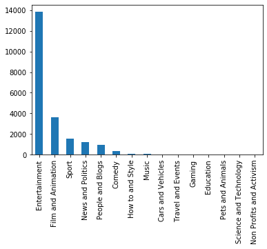

```python
c.plot.bar()
```

#### Top category Entertainment

### Likes vs. View Correlation

```
category_name
Cars and Vehicles         likes    0.996150
                          view     1.000000
Comedy                    likes    0.947100
                          view     1.000000
Education                 likes    0.899470
                          view     1.000000
Entertainment             likes    0.951910
                          view     1.000000
Film and Animation        likes    0.934122
                          view     1.000000
Gaming                    likes    0.999150
                          view     1.000000
How to and Style          likes    0.661305
                          view     1.000000
Music                     likes    0.994788
                          view     1.000000
News and Politics         likes    0.848717
                          view     1.000000
Non Profits and Activism  likes         NaN
                          view          NaN
People and Blogs          likes    0.966836
                          view     1.000000
Pets and Animals          likes    0.999594
                          view     1.000000
Science and Technology    likes    0.822767
                          view     1.000000
Sport                     likes    0.980003
                          view     1.000000
Travel and Events         likes    0.999378
                          view     1.000000
Name: view, dtype: float64
```

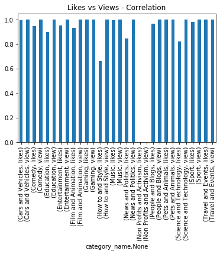

```python
print(data_videos.groupby('category_name')[['likes','view']].corr().view)
data_videos.groupby('category_name')[['likes','view']].corr().view.plot(kind='bar')
plt.title("Likes vs Views - Correlation")
plt.show()
```

#### Looking the Views, likes, dislikes distribuition by category_name's

[figure not shown]

```python
plt.figure(figsize = (14,6))

g = sns.boxplot(x='category_name', y='views_log', data=data_videos, palette="Set1")
g.set_xticklabels(g.get_xticklabels(),rotation=45)
g.set_title("Views Distribuition by Category Names", fontsize=15)
g.set_xlabel("", fontsize=12)
g.set_ylabel("Comments Count(log)", fontsize=12)

plt.show()
```

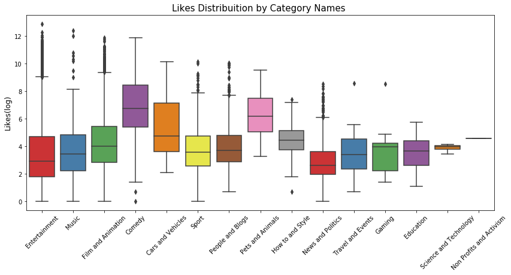

```python
plt.figure(figsize = (14,6))

g = sns.boxplot(x  ='category_name', y = 'likes_log', data = data_videos, palette = "Set1")
g.set_xticklabels(g.get_xticklabels(),rotation = 45)
g.set_title("Likes Distribuition by Category Names ", fontsize = 15)
g.set_xlabel("", fontsize = 12)
g.set_ylabel("Likes(log)", fontsize = 12)
plt.show()
```

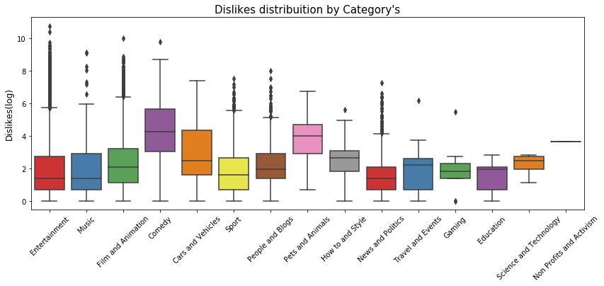

```python
plt.figure(figsize = (14,5))

g = sns.boxplot(x = 'category_name', y = 'dislikes_log', data = data_videos, palette = "Set1")
g.set_xticklabels(g.get_xticklabels(),rotation = 45)
g.set_title("Dislikes distribuition by Category's", fontsize = 15)
g.set_xlabel("", fontsize = 12)
g.set_ylabel("Dislikes(log)", fontsize = 12)
plt.show()
```

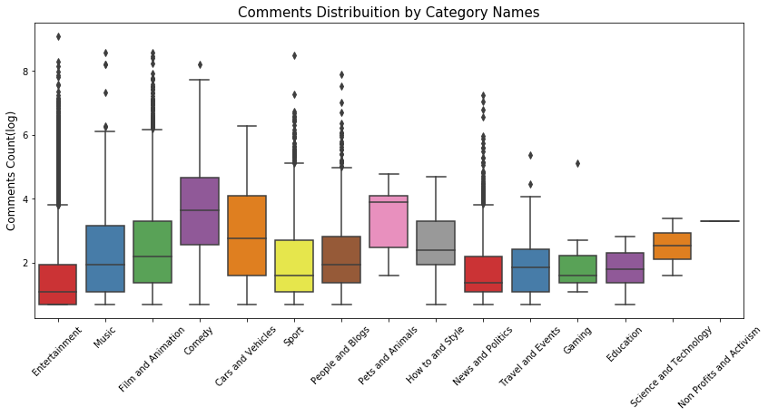

```python
plt.figure(figsize = (14,6))

g = sns.boxplot(x='category_name', y='comment_log', data=data_videos, palette="Set1")
g.set_xticklabels(g.get_xticklabels(),rotation=45)
g.set_title("Comments Distribuition by Category Names", fontsize=15)
g.set_xlabel("", fontsize=12)
g.set_ylabel("Comments Count(log)", fontsize=12)

plt.show()
```